# Regresión lineal

Eric

12/9/2019

Se usa para hacer predicciones. En la regresión lineal se busca la función que relaciona las variables dependiente e independiente. La opción más facil es la relación lineal:

$$y = ax+b$$
con $a, b \in \mathbb{R}$

Buscando que la suma de los cuadrados de las diferencias entre los valores y las aproximaciones sea mínima

$$\sum_{i=1}^n ( y_i - \tilde{y}_i)^2$$

## Como calcular la recta de una regresión lineal

```r
body_fat_df = read.table("../data/bodyfat.txt", header = T)
head(body_fat_df, 3)
```

```
##   Density  Fat Age Weight Height Neck Chest Abdomen  Hip Thigh Knee Ankle
## 1  1.0708 12.3  23 154.25  67.75 36.2  93.1    85.2 94.5  59.0 37.3  21.9
## 2  1.0853  6.1  22 173.25  72.25 38.5  93.6    83.0 98.7  58.7 37.3  23.4
## 3  1.0414 25.3  22 154.00  66.25 34.0  95.8    87.9 99.2  59.6 38.9  24.0
##   Biceps Forearm Wrist
## 1   32.0    27.4  17.1
## 2   30.5    28.9  18.2
## 3   28.8    25.2  16.6
```

```r
fat_weight = body_fat_df[c(2, 4)]
str(fat_weight)
```

```
## 'data.frame':    252 obs. of  2 variables:
##  $ Fat   : num  12.3 6.1 25.3 10.4 28.7 20.9 19.2 12.4 4.1 11.7 ...
##  $ Weight: num  154 173 154 185 184 ...
```

```r
head(fat_weight)
```

```
##    Fat Weight
## 1 12.3 154.25
## 2  6.1 173.25
## 3 25.3 154.00
## 4 10.4 184.75
## 5 28.7 184.25
## 6 20.9 210.25
```

```r
tail(fat_weight)
```

```
##      Fat Weight
## 247 30.2 215.50
## 248 11.0 134.25
## 249 33.6 201.00
## 250 29.3 186.75
## 251 26.0 190.75
## 252 31.9 207.50
```

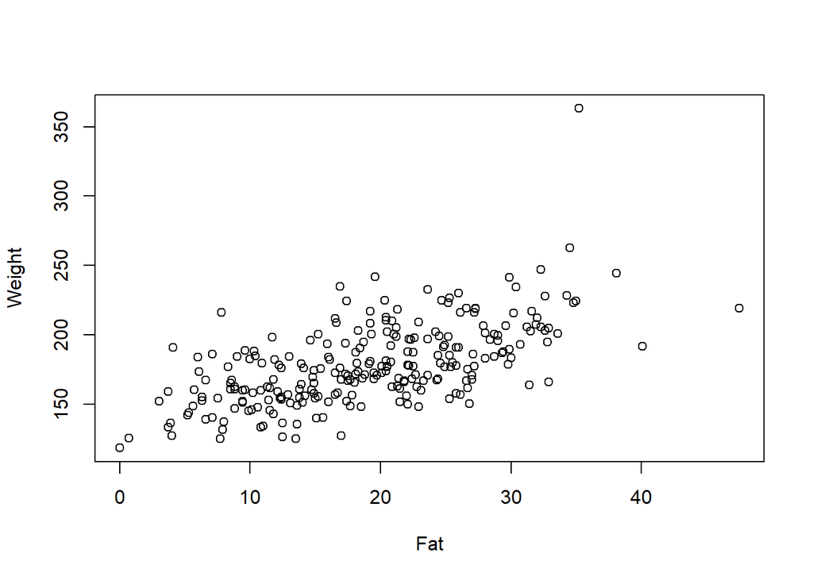

```r
plot(fat_weight)
```

### Calcular la recta de regresión

```r
y = fat_weight$Weight
x = fat_weight$Fat

lm(y~x) # ~ significa "en función de"
```

```
##
## Call:
## lm(formula = y ~ x)
##
## Coefficients:
## (Intercept)            x
##     137.738        2.151
```

```r
lm(Weight~Fat, data = fat_weight)
```

```
##
## Call:
## lm(formula = Weight ~ Fat, data = fat_weight)
##
## Coefficients:
## (Intercept)          Fat
##     137.738        2.151
```

### Interpretar el resultado

Call: lm(formula = Weight ~ Fat, data = fat_weight)

Coefficients: (Intercept) Fat  
resto(?) coeficiente

La función lineal que mejor se ajusta al modelo establecido es la siguiente: $\tilde{y} = coeficiente \cdot x + resto(?)$ ó $\tilde{y} = Fat \cdot x + (Intercept)$

`R` llama *coeficientes* a las incógnitas *a* y *b* pero las da al revés: *a* = Fat, b = (Intercept) (en este caso a = fat porque la variable independiente es fat)

#### Representación

```r
actual_model = lm(Weight~Fat, data = fat_weight)
summary(actual_model)
```

```
##
## Call:
## lm(formula = Weight ~ Fat, data = fat_weight)
##
## Residuals:
##     Min      1Q  Median      3Q     Max
## -46.799 -14.999  -3.469  11.860 149.709
##
## Coefficients:
##             Estimate Std. Error t value Pr(>|t|)
## (Intercept) 137.7375     3.6684   37.55   <2e-16 ***
## Fat           2.1507     0.1756   12.25   <2e-16 ***
## ---
## Signif. codes:  0 '***' 0.001 '**' 0.01 '*' 0.05 '.' 0.1 ' ' 1
##
## Residual standard error: 23.28 on 250 degrees of freedom
## Multiple R-squared:  0.3751, Adjusted R-squared:  0.3726
## F-statistic:   150 on 1 and 250 DF,  p-value: < 2.2e-16
```

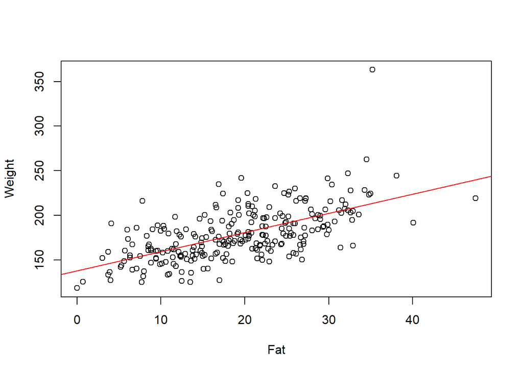

```r
plot(fat_weight)
abline(actual_model, col = "red")
```

## Coeficiente de determinación $\mathit{R}^2$

Es útil para determinar si realmente existe una relación lineal significativa entre los datos y el modelo calculado $R^2 \in [0, 1]$ cuanto más cercano a 1, el ajuste será considerado mejor. Generalmente se considera que si $R^2 > 0.9$ el ajuste es lo suficientemente bueno.

La función lm() devuelve entre otros datos, el coeficiente de determinación, $R^2$. Éste se llama **Multiple R-squared** Y se obtiene de la siguiente manera:

```r
summary(actual_model)$r.squared
```

```
## [1] 0.3750509
```

# Transformaciones logarítmicas

Si en vez de $y = ax+b$ nuestro modelo es $log(y) = ax+b$, los valores log(y) siguen una ley aproximadamente lineal en los valores de x, es decir, los valores de y siguen una relación aproximadamente exponencial en x. Pues se cumple que:

$$y = 10^{log(y)} = 10^{ax+b} = 10^{ax} \cdot 10^b = \alpha^x \beta$$

con $\alpha = 10^a$ y $\beta = 10^b$